# Reproducible Research Project 2

Alan Jenks

19/05/2019

### Synopsis

Storms and other severve weather conditions not only create a huge econdomic problem but can be extremely harmful for popultation health. We consistently see with a variety of severe weather condtions injuries, fatalities, property & food damage which can be devistating to regions or countries.

The project looks at data from the U.S. National Oceanic and Atmospheric Administration’s (NOAA) storm datatbase.

The database contains data from 1950 to the end of November 2011. The data is an accumulation of events and characteristics of storms in the United States looking at where they occur, damage and fatalities and injuries.

This report analyzes the storm event records in the severe weather tracking database to determine which of these event types has the most impact in terms of harm to human health and property damage.

###Data Processing

Data processing will involve first loading the libraries I will use for this project. I will then download the zip file, unzip it and process the file into a table. I will run some preliminary views of the table to look for items I can pull out and evaluate for the two questions which are which weather condition or conditions has the most impact on personal healh and which storm conditions have the greatest economic impact.

Once the files are downloaded and put in tables. I will isolate the needed variables and clean the data to look at creating some initial plots to see what the dat says.

## Load Libraries

```r
library(data.table)
library(dplyr)
library(plyr)
library(stats)
library(R.utils)
library(RColorBrewer)
library(knitr)
library(markdown)
library(rmarkdown)
library(tools)
```

## Get Data

#Downaload raw data and read the csv

```r
fileurl <- "https://d396qusza40orc.cloudfront.net/repdata%2Fdata%2FStormData.csv.bz2"
if (!file.exists('./repdata%2Fdata%2FStormData.csv.bz2')){
  download.file(fileurl,'./repdata%2Fdata%2FStormData.csv.bz2', mode = 'wb')
  bunzip2("repdata%2Fdata%2FStormData.csv.bz2", "repdata%2Fdata%2FStormData.csv", remove = FALSE, skip = TRUE)
}
##read file
storm <- read.csv('repdata%2Fdata%2FStormData.csv')
dim(storm)
```

```
## [1] 902297     37
```

902297 data points in 37 columns

```r
head(storm)
```

```
##   STATE__           BGN_DATE BGN_TIME TIME_ZONE COUNTY COUNTYNAME STATE
## 1       1  4/18/1950 0:00:00     0130       CST     97     MOBILE    AL
## 2       1  4/18/1950 0:00:00     0145       CST      3    BALDWIN    AL
## 3       1  2/20/1951 0:00:00     1600       CST     57    FAYETTE    AL
## 4       1   6/8/1951 0:00:00     0900       CST     89    MADISON    AL
## 5       1 11/15/1951 0:00:00     1500       CST     43    CULLMAN    AL
## 6       1 11/15/1951 0:00:00     2000       CST     77 LAUDERDALE    AL
##    EVTYPE BGN_RANGE BGN_AZI BGN_LOCATI END_DATE END_TIME COUNTY_END
## 1 TORNADO         0                                               0
## 2 TORNADO         0                                               0
## 3 TORNADO         0                                               0
## 4 TORNADO         0                                               0
## 5 TORNADO         0                                               0
## 6 TORNADO         0                                               0
##   COUNTYENDN END_RANGE END_AZI END_LOCATI LENGTH WIDTH F MAG FATALITIES
```

[output cut: 20 more lines]

```r
names(storm)
```

```
##  [1] "STATE__"    "BGN_DATE"   "BGN_TIME"   "TIME_ZONE"  "COUNTY"
##  [6] "COUNTYNAME" "STATE"      "EVTYPE"     "BGN_RANGE"  "BGN_AZI"
## [11] "BGN_LOCATI" "END_DATE"   "END_TIME"   "COUNTY_END" "COUNTYENDN"
## [16] "END_RANGE"  "END_AZI"    "END_LOCATI" "LENGTH"     "WIDTH"
## [21] "F"          "MAG"        "FATALITIES" "INJURIES"   "PROPDMG"
## [26] "PROPDMGEXP" "CROPDMG"    "CROPDMGEXP" "WFO"        "STATEOFFIC"
## [31] "ZONENAMES"  "LATITUDE"   "LONGITUDE"  "LATITUDE_E" "LONGITUDE_"
## [36] "REMARKS"    "REFNUM"
```

```r
str(storm)
```

```
## 'data.frame':    902297 obs. of  37 variables:
##  $ STATE__   : num  1 1 1 1 1 1 1 1 1 1 ...
##  $ BGN_DATE  : Factor w/ 16335 levels "1/1/1966 0:00:00",..: 6523 6523 4242 11116 2224 2224 2260 383 3980 3980 ...
##  $ BGN_TIME  : Factor w/ 3608 levels "00:00:00 AM",..: 272 287 2705 1683 2584 3186 242 1683 3186 3186 ...
##  $ TIME_ZONE : Factor w/ 22 levels "ADT","AKS","AST",..: 7 7 7 7 7 7 7 7 7 7 ...
##  $ COUNTY    : num  97 3 57 89 43 77 9 123 125 57 ...
##  $ COUNTYNAME: Factor w/ 29601 levels "","5NM E OF MACKINAC BRIDGE TO PRESQUE ISLE LT MI",..: 13513 1873 4598 10592 4372 10094 1973 23873 24418 4598 ...
##  $ STATE     : Factor w/ 72 levels "AK","AL","AM",..: 2 2 2 2 2 2 2 2 2 2 ...
##  $ EVTYPE    : Factor w/ 985 levels "   HIGH SURF ADVISORY",..: 834 834 834 834 834 834 834 834 834 834 ...
##  $ BGN_RANGE : num  0 0 0 0 0 0 0 0 0 0 ...
##  $ BGN_AZI   : Factor w/ 35 levels "","  N"," NW",..: 1 1 1 1 1 1 1 1 1 1 ...
##  $ BGN_LOCATI: Factor w/ 54429 levels "","- 1 N Albion",..: 1 1 1 1 1 1 1 1 1 1 ...
##  $ END_DATE  : Factor w/ 6663 levels "","1/1/1993 0:00:00",..: 1 1 1 1 1 1 1 1 1 1 ...
##  $ END_TIME  : Factor w/ 3647 levels ""," 0900CST",..: 1 1 1 1 1 1 1 1 1 1 ...
##  $ COUNTY_END: num  0 0 0 0 0 0 0 0 0 0 ...
```

[output cut: 23 more lines]

The dataset has a total of 902297 records

This report focuses on the information related to: - Type of Event recorded in column 8 labeled EVTYPE - Number of fatalities recorded in column 23 labeled FATALITIES - Number of injuries recorded in column 24 labeled INJURIES - Amount of property damage recorded in column 25 & 26, labeled PROPDMG & PROPDMGEP - Amount of crop damage recorded in columnS 27 & 28 labeled CROPDMG & CROPDMGEXP

##Code to subset the dataset for fields of interest

```r
sd <- subset(storm[,c(8,23,24,25,26,27,28,29)])
```

###1. Across the United States, which types of events (as indicated in the EVTYPE variable) are most harmful with respect to population health?

##To determine which type of events are most harmful to the population health we must look at the variables fatalities and Injuries.

#Fatalities

```r
sumFatalities <- aggregate(FATALITIES ~ EVTYPE, data = sd,  FUN="sum")
dim(sumFatalities)
```

```
## [1] 985   2
```

```r
fatalitiesTop10 <- sumFatalities[order(-sumFatalities$FATALITIES), ][1:10, ]
dim(fatalitiesTop10)
```

```
## [1] 10  2
```

```r
fatalitiesTop10
```

```
##             EVTYPE FATALITIES
## 834        TORNADO       5633
## 130 EXCESSIVE HEAT       1903
## 153    FLASH FLOOD        978
## 275           HEAT        937
## 464      LIGHTNING        816
## 856      TSTM WIND        504
## 170          FLOOD        470
## 585    RIP CURRENT        368
## 359      HIGH WIND        248
## 19       AVALANCHE        224
```

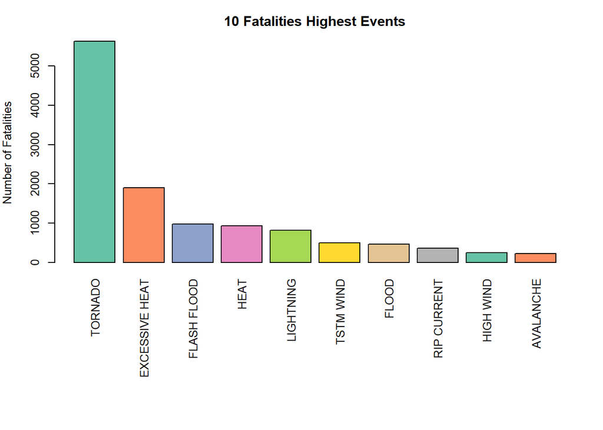

```r
par(mfrow = c(1,1), mar = c(12, 4, 3, 2), mgp = c(3, 1, 0), cex = 0.8)
barplot(fatalitiesTop10$FATALITIES, names.arg = fatalitiesTop10$EVTYPE, las = 3, main = "10 Fatalities Highest Events", ylab = "Number of Fatalities", col = c(brewer.pal(n = 10, name = "Set2")))
```

```r
dev.copy(png, "cropdmg-total.png", width = 480, height = 480)
```

```r
dev.off()
```

#Injuries

```r
sumInjuries <- aggregate(INJURIES ~ EVTYPE, data = storm,  FUN="sum")
dim(sumInjuries)
```

```
## [1] 985   2
```

```r
injuriesTop10 <- sumInjuries[order(-sumInjuries$INJURIES), ][1:10, ]
dim(injuriesTop10)
```

```
## [1] 10  2
```

```r
injuriesTop10
```

```
##                EVTYPE INJURIES
## 834           TORNADO    91346
## 856         TSTM WIND     6957
## 170             FLOOD     6789
## 130    EXCESSIVE HEAT     6525
## 464         LIGHTNING     5230
## 275              HEAT     2100
## 427         ICE STORM     1975
## 153       FLASH FLOOD     1777
## 760 THUNDERSTORM WIND     1488
## 244              HAIL     1361
```

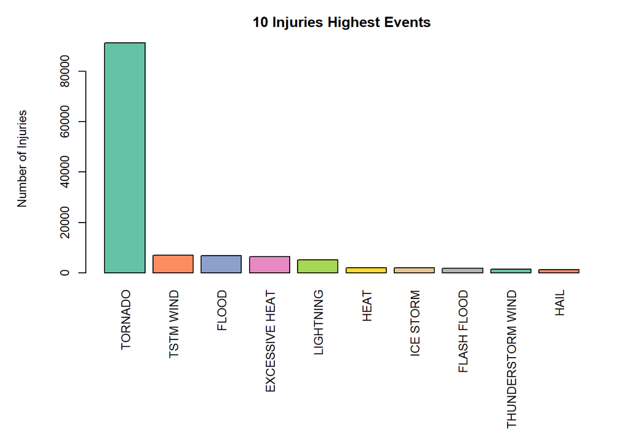

```r
par(mfrow = c(1,1), mar = c(12, 6, 3, 2), mgp = c(4, 1, 0), cex = 0.8)
barplot(injuriesTop10$INJURIES, names.arg = injuriesTop10$EVTYPE, las = 3, main = "10 Injuries Highest Events", ylab = "Number of Injuries", col = c(brewer.pal(n = 10, name = "Set2")))
```

```r
dev.copy(png, "cropdmg-total.png", width = 480, height = 480)
```

```r
dev.off()
```

###2. Across the United States, which types of events have the greatest economic consequences?

##Property Damage

```r
unique(storm$PROPDMGEXP)
```

```
##  [1] K M   B m + 0 5 6 ? 4 2 3 h 7 H - 1 8
## Levels:  - ? + 0 1 2 3 4 5 6 7 8 B h H K m M
```

```r
storm$PROPDMGEXP <- mapvalues(storm$PROPDMGEXP, from = c("K", "M","", "B", "m", "+", "0", "5", "6", "?", "4", "2", "3", "h", "7", "H", "-", "1", "8"), to = c(10^3, 10^6, 1, 10^9, 10^6, 0,1,10^5, 10^6, 0, 10^4, 10^2, 10^3, 10^2, 10^7, 10^2, 0, 10, 10^8))
storm$PROPDMGEXP <- as.numeric(as.character(storm$PROPDMGEXP))
storm$PROPDMGTOTAL <- (storm$PROPDMG * storm$PROPDMGEXP)/1000000000
unique(storm$CROPDMGEXP)
```

```
## [1]   M K m B ? 0 k 2
## Levels:  ? 0 2 B k K m M
```

```r
storm$CROPDMGEXP <- mapvalues(storm$CROPDMGEXP, from = c("","M", "K", "m", "B", "?", "0", "k","2"), to = c(1,10^6, 10^3, 10^6, 10^9, 0, 1, 10^3, 10^2))
storm$CROPDMGEXP <- as.numeric(as.character(storm$CROPDMGEXP))
storm$CROPDMGTOTAL <- (storm$CROPDMG * storm$CROPDMGEXP)/1000000000
```

```r
sumPropertyDamage <- aggregate(PROPDMGTOTAL ~ EVTYPE, data = storm, FUN="sum")
dim(sumPropertyDamage)
```

```
## [1] 985   2
```

```r
propdmg10Total <- sumPropertyDamage[order(-sumPropertyDamage$PROPDMGTOTAL), ][1:10, ]
propdmg10Total
```

```
##                EVTYPE PROPDMGTOTAL
## 170             FLOOD   144.657710
## 411 HURRICANE/TYPHOON    69.305840
## 834           TORNADO    56.947381
## 670       STORM SURGE    43.323536
## 153       FLASH FLOOD    16.822674
## 244              HAIL    15.735268
## 402         HURRICANE    11.868319
## 848    TROPICAL STORM     7.703891
## 972      WINTER STORM     6.688497
## 359         HIGH WIND     5.270046
```

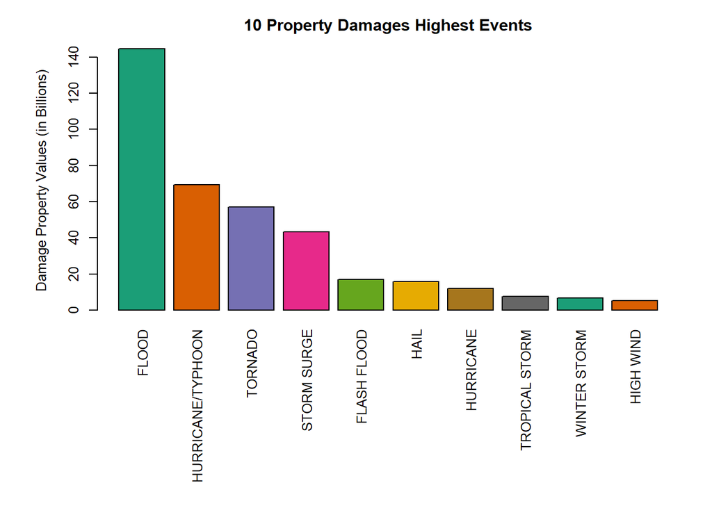

```r
par(mfrow = c(1,1), mar = c(12, 6, 3, 2), mgp = c(3, 1, 0), cex = 0.8)
barplot(propdmg10Total$PROPDMGTOTAL, names.arg = propdmg10Total$EVTYPE, las = 3, main = "10 Property Damages Highest Events", ylab = "Damage Property Values (in Billions)", col = c(brewer.pal(n = 10, name = "Dark2")))
```

```r
dev.copy(png, "cropdmg-total.png", width = 480, height = 480)
```

```r
dev.off()
```

##Crop Damage

```r
sumCropDamage <- aggregate(CROPDMGTOTAL ~ EVTYPE, data = storm,  FUN="sum")
dim(sumCropDamage)
```

```
## [1] 985   2
```

```r
cropdmg10Total <- sumCropDamage[order(-sumCropDamage$CROPDMGTOTAL), ][1:10, ]
cropdmg10Total
```

```
##                EVTYPE CROPDMGTOTAL
## 95            DROUGHT    13.972566
## 170             FLOOD     5.661968
## 590       RIVER FLOOD     5.029459
## 427         ICE STORM     5.022113
## 244              HAIL     3.025954
## 402         HURRICANE     2.741910
## 411 HURRICANE/TYPHOON     2.607873
## 153       FLASH FLOOD     1.421317
## 140      EXTREME COLD     1.292973
## 212      FROST/FREEZE     1.094086
```

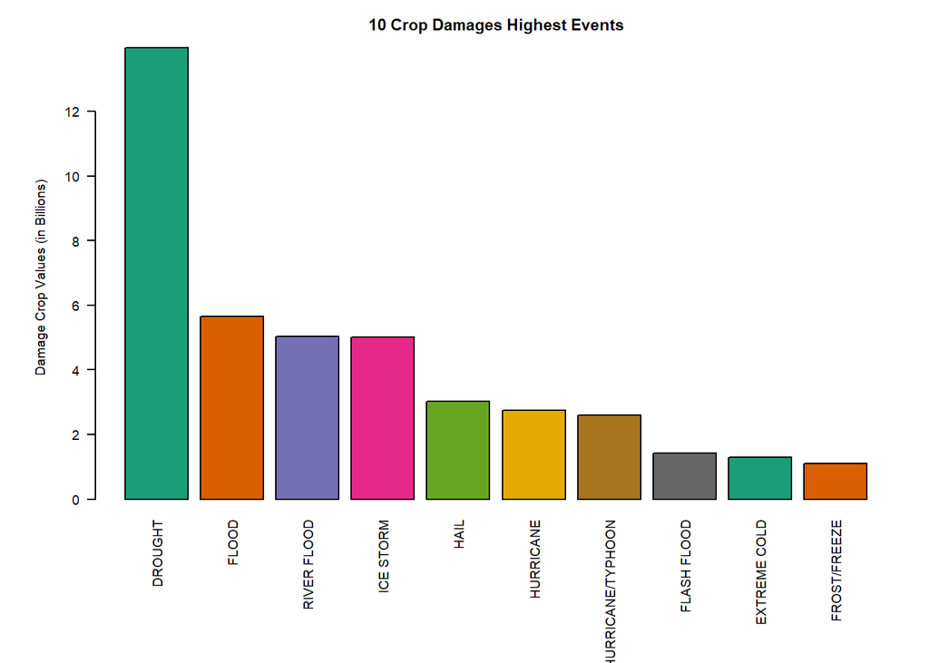

```r
par(mfrow = c(1,1), mar = c(10, 6, 3, 2), mgp = c(3, 1, 0), cex = 0.6)
barplot(cropdmg10Total$CROPDMGTOTAL, names.arg = cropdmg10Total$EVTYPE, las = 2, main = "10 Crop Damages Highest Events", ylab = "Damage Crop Values (in Billions) ", col = c(brewer.pal(n = 10, name = "Dark2")))
```

```r
dev.copy(png, "cropdmg-total.png", width = 480, height = 480)
```

```r
dev.off()
```

###Results

## Question 1 - Which is the most harmful with respect to population health?

When we look at injuries and fatalities based on the storm data Tornados are the clear winner as far as the most harmful with respect to population health.

## Question 2 - Across the United States, which types of events have the greatest economic consequences?

Looking at the economic variables which would relate to crop damage and property damage, the data support that floods are the winner with regards to property damage economically and with regards to crop damage drought is by far the winner.